# 1. Generalization

## 1.5 Image Augmentation

Image Augmentation allows the dataset to increase by modifying the existing images by using a zoom, a skew, random distortions etc to increase the size of the dataset without having to collect more unique data. To preform this task I decided to use the Augmentor Python library. The library uses a Pipe-line which is connected to the original source directory of images. Augmentor has their output directory hardcoded to create a new directory known simply as output in the original categories folder. To manage this I manually moved the newly created images to a new folder which would hold all the outputted images. This was preformed on both the Categories in the dataset and the newly created data was brought into one folder.

### 1.5.1 Create the Augmented Images - Healthy

#### 1.5.1.1 Create the Augmentor

```python
import Augmentor
p = Augmentor.Pipeline("DATA/Healthy")
```

```
Initialised with 250 image(s) found.
Output directory set to DATA/Healthy\output.
```

#### 1.5.1.2 Initialise the Modifications

```python
p.zoom(probability=0.4, min_factor=1.1, max_factor=1.5)
p.skew(probability=0.2)
p.random_distortion(probability=0.2, grid_width=6, grid_height=6, magnitude=16)
p.rotate(probability=0.4, max_left_rotation=10, max_right_rotation=10)
p.shear(probability=0.2, max_shear_left=6, max_shear_right=6)
p.flip_random(probability=0.4)
p.skew_tilt(probability=0.4)
```

#### 1.5.1.3 Augment the Data-set

1500 images were created. Instead of adding an extreme value for this parameter a small value such as 1500 ensures that the modifications will not create distorted images which would serve no overall use to the training of this model.

```python
p.sample(1500)
```

```
Processing <PIL.Image.Image image mode=RGB size=1365x1365 at 0x23FC3517400>: 100%|█| 1500/1500 [00:14<00:00, 100.17 Samples/s]
```

### 1.5.2 Create the Augmented Images - Un-Healthy

#### 1.5.2.1 Create the Augmentor

```python
import Augmentor
p = Augmentor.Pipeline("DATA/Un-Healthy")
```

```
Initialised with 250 image(s) found.
Output directory set to DATA/Un-Healthy\output.
```

#### 1.5.2.2 Initialise the Modifications

```python
p.zoom(probability=0.4, min_factor=1.1, max_factor=1.5)
p.skew(probability=0.2)
p.random_distortion(probability=0.2, grid_width=6, grid_height=6, magnitude=16)
p.rotate(probability=0.4, max_left_rotation=10, max_right_rotation=10)
p.shear(probability=0.2, max_shear_left=6, max_shear_right=6)
p.flip_random(probability=0.4)
p.skew_tilt(probability=0.4)
```

#### 1.5.2.3 Augment the Data-set

```python
p.sample(1500)
```

```
Processing <PIL.JpegImagePlugin.JpegImageFile image mode=RGB size=206x254 at 0x23FDD05CE48>: 100%|█| 1500/1500 [00:21<00:00, 70.65 Samples/s]
```

### 1.5.3 Pre-process the Augmented Images

#### 1.5.3.1 Read in the Images

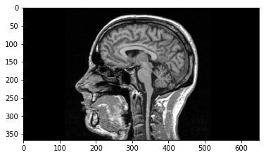

```python
import numpy as np
import matplotlib.pyplot as plt
import os
import cv2

%matplotlib inline

DATADIR = "AUG_DATA"
CATEGORIES = ["Healthy", "Un-Healthy"]

for category in CATEGORIES:
    path = os.path.join(DATADIR, category)
    for img in os.listdir(path):
        img_array = cv2.imread(os.path.join(path,img), cv2.IMREAD_GRAYSCALE)
        blur = cv2.GaussianBlur(img_array,(5,5),0)
        plt.imshow(blur, cmap="gray")
        plt.show()
        break
    break
```

#### 1.5.3.2 Resize the Images

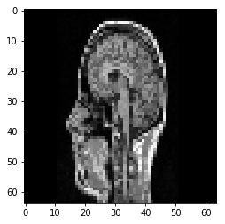

```python
IMG_SIZE = 64

new_array = cv2.resize(blur, (IMG_SIZE, IMG_SIZE))
plt.imshow(new_array, cmap = "gray")
plt.show()
```

#### 1.5.3.3 Create the Training Set

```python
training_data = []

def create_training_data():
    for category in CATEGORIES:
        path = os.path.join(DATADIR, category)
        class_num = CATEGORIES.index(category)
        for img in os.listdir(path):
            try:
                img_array = cv2.imread(os.path.join(path, img), cv2.IMREAD_GRAYSCALE)
                blur = cv2.GaussianBlur(img_array,(5,5),0)
                new_array = cv2.resize(blur, (IMG_SIZE, IMG_SIZE))
                training_data.append([new_array, class_num])
            except Exception as e:
                pass

create_training_data()
```

#### 1.5.3.4 Print the Length of the Data

```python
print(len(training_data))
```

```
3500
```

#### 1.5.3.5 Randomly shuffle the Data

```python
import random

random.shuffle(training_data)
```

#### 1.5.3.6 Create X & Y

```python
X = []
y = []
```

#### 1.5.3.7 Create the Labels

```python
for features, label in training_data:
    X.append(features)
    y.append(label)

X = np.array(X).reshape(-1, IMG_SIZE, IMG_SIZE, 1)
```

#### 1.5.3.8 Write the Data into Pickle FIles

```python
import pickle

pickle_out = open("X_aug.pickle", "wb")
pickle.dump(X, pickle_out)
pickle_out.close()

pickle_out = open("y_aug.pickle", "wb")
pickle.dump(y, pickle_out)
pickle_out.close()
```

### 1.5.4 Test the Augmented Images - No Generalization

Here I wanted to test out how the model would preform based on the results recorded from the grid search stage.

#### 1.5.4.1 Import the Libraries

```python
import tensorflow as tf
import numpy as np
import matplotlib
import matplotlib.pyplot as plt
from tensorflow.keras.models import Sequential
from tensorflow.keras.layers import Dense, Dropout, Activation, Flatten, Conv2D, MaxPooling2D, AveragePooling2D, GaussianNoise
from tensorflow.python.keras.optimizers import Adam, SGD, RMSprop, Adagrad
import pickle

%matplotlib inline
```

#### 1.5.4.2 Set the Random Seed

```python
np.random.seed(1)
```

#### 1.5.4.3 Read in the Data

```python
X = pickle.load(open("X_aug.pickle","rb"))
y = pickle.load(open("y_aug.pickle","rb"))
```

#### 1.5.4.4 Normalise the Data

```python
X = X/255.0
```

#### 1.5.4.4 Create the Model

```python
model = Sequential()

model.add(Conv2D(16, (3,3), dilation_rate=2, strides=1, kernel_initializer='normal', input_shape = X.shape[1:]))
model.add(Activation("relu"))
model.add(MaxPooling2D(pool_size=(2,2), padding="same"))

model.add(Conv2D(32, (3,3), dilation_rate=2, strides=1, kernel_initializer='normal'))
model.add(Activation("relu"))
model.add(MaxPooling2D(pool_size=(2,2), padding="same"))

model.add(Conv2D(64, (3,3), dilation_rate=2, strides=1, kernel_initializer='normal'))
model.add(Activation("relu"))
model.add(MaxPooling2D(pool_size=(2,2), padding="same"))

model.add(Conv2D(128, (3,3), dilation_rate=2, strides=1, kernel_initializer='normal'))
model.add(Activation("relu"))
model.add(MaxPooling2D(pool_size=(2,2), padding="same"))

model.add(Flatten())
model.add(Dense(32, kernel_initializer='normal'))
model.add(Activation("relu"))

model.add(Dense(32, kernel_initializer='normal'))
model.add(Activation("relu"))

model.add(Dense(32, kernel_initializer='normal'))
model.add(Activation("relu"))

model.add(Dense(1))
model.add(Activation("sigmoid"))

optimizer = Adamax(lr=0.01)

model.compile(loss="binary_crossentropy",
             optimizer=optimizer,
             metrics=['accuracy'])
```

#### 1.5.4.5 Fit the Model

```python
aug_3500 = model.fit(X, y, batch_size=64, epochs=50, validation_split=0.33)
```

```
Train on 2344 samples, validate on 1156 samples
```

#### 1.5.4.6 Visualise the Results

With this increase in data it is now evident that the model converges easily after the 20-30 epoch range. However, the model is overfitting and will require generalisation techniques to tackle this issue.

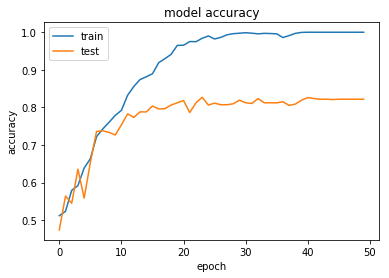

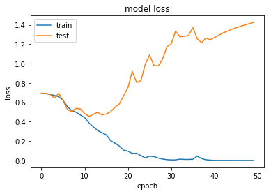

```python
plt.plot(aug_3500.history['acc'])
plt.plot(aug_3500.history['val_acc'])
plt.title('model accuracy')
plt.ylabel('accuracy')
plt.xlabel('epoch')
plt.legend(['train', 'test'], loc='upper left')
plt.show()

plt.plot(aug_3500.history['loss'])
plt.plot(aug_3500.history['val_loss'])
plt.title('model loss')
plt.ylabel('loss')
plt.xlabel('epoch')
plt.legend(['train', 'test'], loc='upper left')
plt.show()
```

### 1.5.5 Test the Augmented Images - Generalization

#### 1.5.5.1 Create the Model

```python
model = Sequential()

model.add(Conv2D(16, (3,3), dilation_rate=2, strides=1, kernel_initializer='normal', use_bias=True, input_shape = X.shape[1:]))
model.add(Activation("relu"))
model.add(MaxPooling2D(pool_size=(2,2), padding="same"))
model.add(Dropout(0.3))

model.add(Conv2D(32, (3,3), dilation_rate=2, strides=1, kernel_initializer='normal', use_bias=True))
model.add(Activation("relu"))
model.add(MaxPooling2D(pool_size=(2,2), padding="same"))
model.add(Dropout(0.3))

model.add(Conv2D(64, (3,3), dilation_rate=2, strides=1, kernel_initializer='normal', use_bias=True))
model.add(Activation("relu"))
model.add(MaxPooling2D(pool_size=(2,2), padding="same"))
model.add(Dropout(0.3))

model.add(Conv2D(128, (3,3), dilation_rate=2, strides=1, kernel_initializer='normal', use_bias=True))
model.add(Activation("relu"))
model.add(MaxPooling2D(pool_size=(2,2), padding="same"))
model.add(Dropout(0.3))

model.add(Flatten())
model.add(Dense(64, kernel_initializer='normal', use_bias=True))
model.add(GaussianNoise(0.2))
model.add(Activation("relu"))
model.add(Dropout(0.1))

model.add(Dense(64, kernel_initializer='normal', use_bias=True))
model.add(GaussianNoise(0.2))
model.add(Activation("relu"))
model.add(Dropout(0.1))

model.add(Dense(64, kernel_initializer='normal', use_bias=True))
model.add(GaussianNoise(0.2))
model.add(Activation("relu"))
model.add(Dropout(0.1))

model.add(Dense(1))
model.add(Activation("sigmoid"))

optimizer = Adamax(lr=0.01)

model.compile(loss="binary_crossentropy",
             optimizer=optimizer,
             metrics=['accuracy'])
```

#### 1.5.5.2 Fit the Model

```python
aug_3500_Gen = model.fit(X, y, batch_size=64, epochs=50, validation_split=0.33)
```

```
Train on 2344 samples, validate on 1156 samples
```

#### 1.5.5.3 Visualise the Results

This is the final model recorded using the values for generalisation recorded early on in the notebook. The model is still slightly overfitting but an increase in dropout rate on either layer fixed this issue, it instead cause the model to spike.

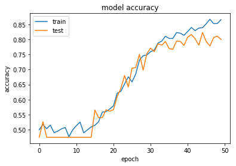

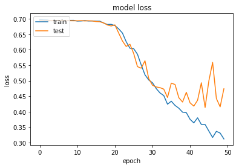

```python
plt.plot(aug_3500_Gen.history['acc'])
plt.plot(aug_3500_Gen.history['val_acc'])
plt.title('model accuracy')
plt.ylabel('accuracy')
plt.xlabel('epoch')
plt.legend(['train', 'test'], loc='upper left')
plt.show()

plt.plot(aug_3500_Gen.history['loss'])
plt.plot(aug_3500_Gen.history['val_loss'])
plt.title('model loss')
plt.ylabel('loss')
plt.xlabel('epoch')
plt.legend(['train', 'test'], loc='upper left')
plt.show()
```

## 1.6 Save the Final Model

```python
model.save("CNN_AUGMENTED.model") # USING AUGMENTED DATA
```